# Capítulo 5

```r
library(tidyverse)
```

```r
library(dplyr)
library(gapminder)
library(socviz)
```

# 1 Usando o operador pipe

Muitas das vezes necessitamos realizar uma série de operações sucessivas com o nosso dado. Atribuir uma variável para cada uma dessas operações, pode se tornar inviável Para isso, o tideverse nos oferece um operador muito útil, o operador pipe (%>%). Essa série de caracteres nos mostra que o que foi feito anteriormente deve ser entendido como primeiro argumento do próximo comando.

```r
rel_por_religiao <- gss_sm %>%
  group_by(bigregion, religion) %>%
  summarize(N = n()) %>%
  mutate(freq = N / sum(N), pct = round(freq*100), 0)
rel_por_religiao
```

```
## # A tibble: 24 × 6
## # Groups:   bigregion [4]
##    bigregion religion       N    freq   pct   `0`
##    <fct>     <fct>      <int>   <dbl> <dbl> <dbl>
##  1 Northeast Protestant   158 0.324      32     0
##  2 Northeast Catholic     162 0.332      33     0
##  3 Northeast Jewish        27 0.0553      6     0
##  4 Northeast None         112 0.230      23     0
##  5 Northeast Other         28 0.0574      6     0
##  6 Northeast <NA>           1 0.00205     0     0
##  7 Midwest   Protestant   325 0.468      47     0
##  8 Midwest   Catholic     172 0.247      25     0
##  9 Midwest   Jewish         3 0.00432     0     0
## 10 Midwest   None         157 0.226      23     0
## # ℹ 14 more rows
```

Neste caso por exemplo, pegamos a nossa base de dados, a partir dela, agrupamos por regiões e por religião, criamos uma nova coluna com a frequência de cada classe, e depois criamos mais duas coluna, uma com a frequência relativa de cada ocorrência, e por fim uma coluna com a porcentagem.

# 2 Invertendo os eixos

Utilizando as tabela que acabamos de fazer, podemos tentar realizar os mesmos gráficos feitos no capítulo 4, na qual agrupamos por região e por religião. No entanto, agora que temos os dados manipulados do jeito que queremos, trabalhar com esses dados será mais fácil.

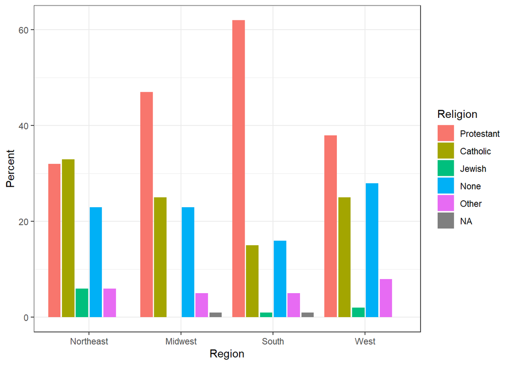

```r
q_1 <- ggplot(rel_por_religiao, aes(x = bigregion, y = pct, fill = religion))
q_1 + geom_col(position = "dodge2") +
  labs(x = "Region", y = "Percent", fill = "Religion") +
  theme(legend.position = "top") + theme_bw()
```

Note que esse gráfico está muito legal, no entanto podemos melhora-lo ainda mais. Quando plotamos todos no mesmo gráfico, não conseguimos identificar o que é o que. Assim, dividir esses gráficos em outros, fará o nosso gráfico ficar melhor. Podemos tentar inverter o nosso gráfico, para assim fazer um gráfico de barras e tornar a compreensão ainda mais fácil, pois assim não precisaremos de legendas.

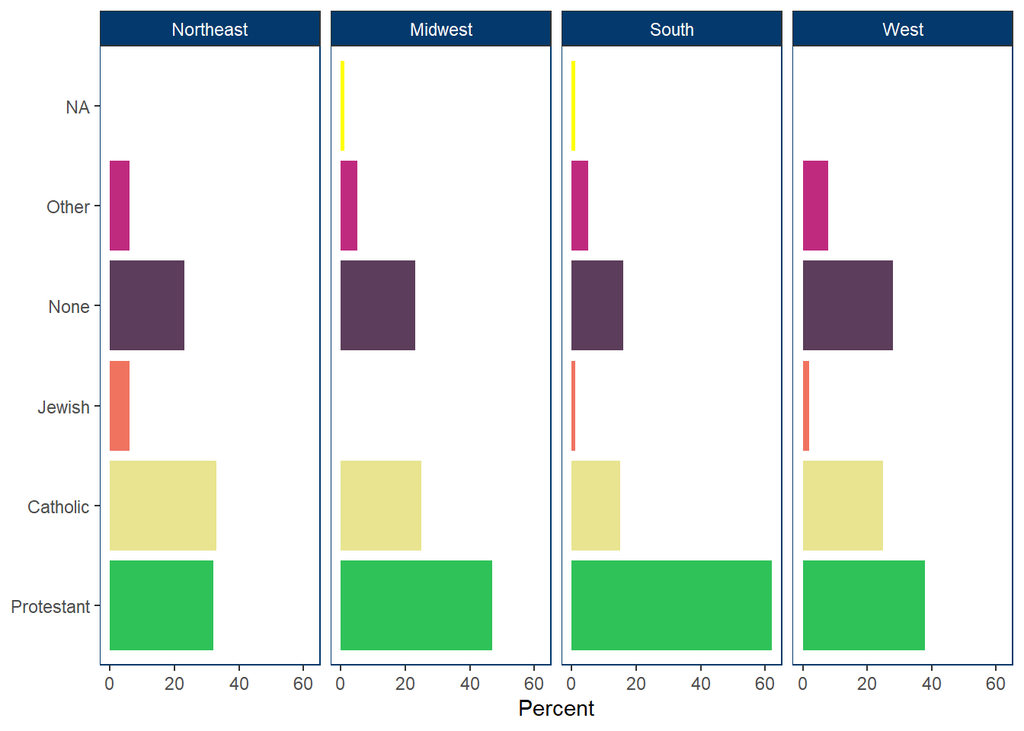

```r
cores <- c("#2fc258", "#e8e490", "#f07360", "#5c3d5b", "#bf2a7f", "yellow")
cores_x4 <- c(cores, cores, cores, cores)
q_2 <- ggplot(rel_por_religiao, aes(x = religion, y = pct, fill = religion))
q_2 + geom_col(position = "dodge2",
               fill = cores_x4) +
  labs(x= NULL, y = "Percent", fill = "Religion") +
  guides(fill = "none") +
  coord_flip() +
  facet_grid(~ bigregion) +
  theme_bw() +
  theme(strip.background = element_rect(fill ="#03396c"),
        strip.text = element_text(color = "white"),
        panel.border = element_rect(color = "#03396c", fill = NA),
        panel.grid = element_blank())
```

# 3 Variáveis continuas por grupo ou categoria

Vamos agora utilizar a tabela do Organdata. e fazer alguns plots para entender o dado. Primeiro vamos plotar como que foi a distribuição das doações por ano. Cada ponto no gráfico representa um país.

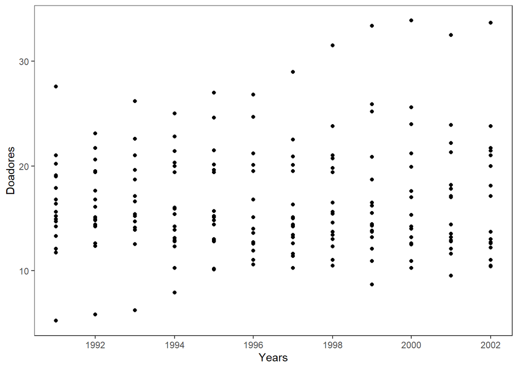

```r
q_2 <- ggplot(organdata, aes(x = year, y = donors))
q_2 +
  geom_point() +
  theme_bw() +
  labs(x = "Years",
       y = "Doadores") +
  theme(panel.grid = element_blank())
```

Vamos agora dividir por país.

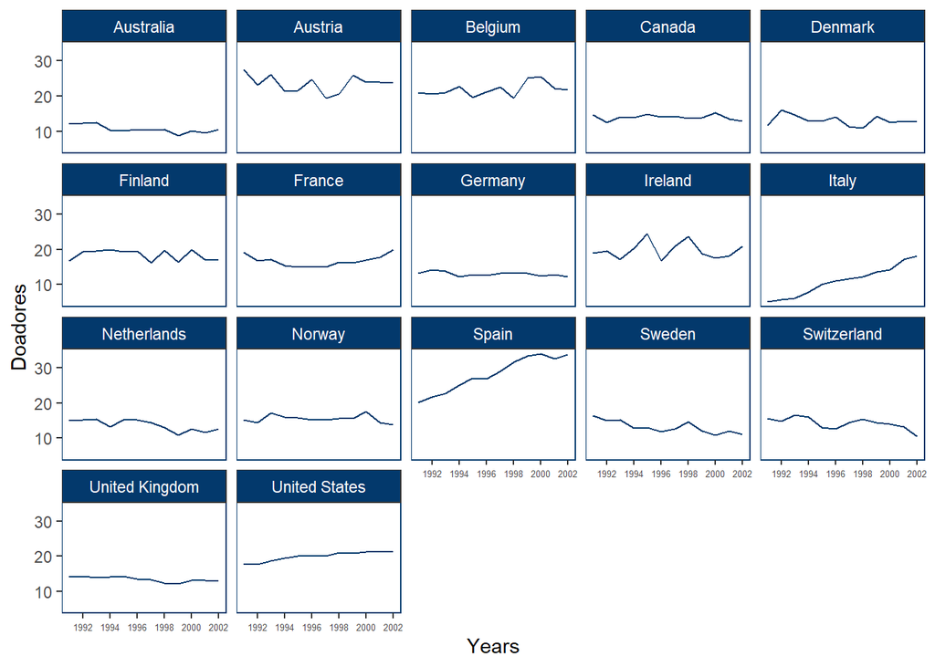

```r
q_2 + geom_line(aes(group = country), color= "#03396c") +
  facet_wrap(~country) +
  theme_bw() +
  labs(x = "Years",
       y = "Doadores") +
  theme(axis.text.x = element_text(size = 5),
        panel.grid = element_blank(),
        strip.background = element_rect(fill ="#03396c"),
        strip.text = element_text(color = "white"),
        panel.border = element_rect(color = "#03396c", fill = NA))
```

Note que um gráfico de linhas é legal, e nos dá uma ideia de como o número de doadores está se comportando ao longo do tempo. No entanto esta não é a única forma de representar os dados. Uma outra maneira é por meio de um box plot. Vamos gira-lo para que possamos escapara da sobreposição de nomes nos países

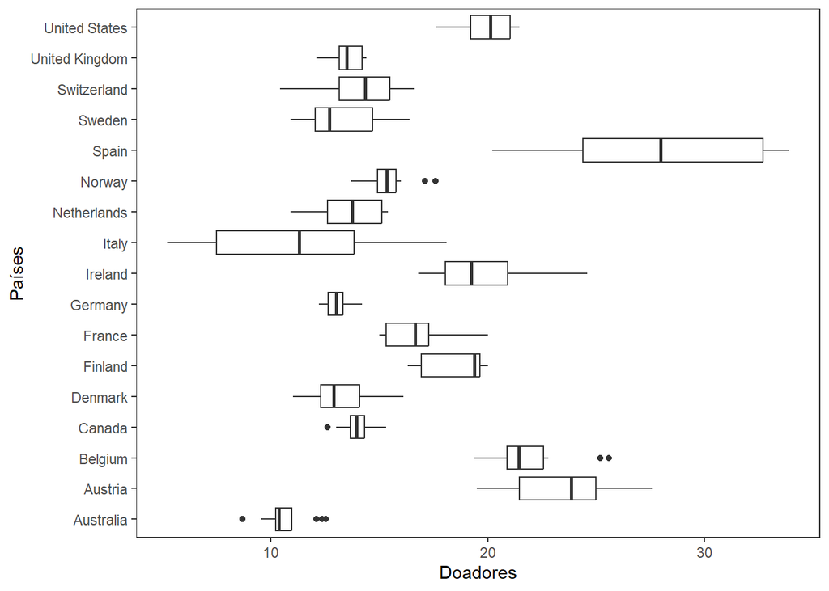

```r
q_3 <- ggplot(data = organdata, aes(x = country, y = donors))
q_3 +
  geom_boxplot() +
  coord_flip() +
  theme_bw() +
  theme(panel.grid = element_blank()) +
  labs(y = "Doadores", x= "Países")
```

No entando o gráfico está feio, pois não temos nenhuma ordem para como ele está disposto. para melhorar isso, usaremos a função reorder, e adicionaremos algumas cores

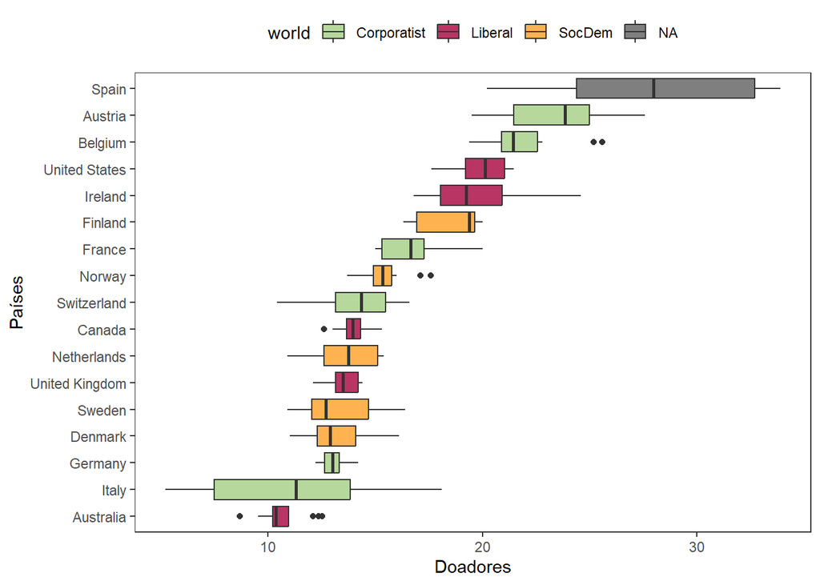

```r
q_4 <- ggplot(data = organdata,
              aes(x = reorder(country,
                              donors,
                              na.rm = TRUE),
                  y = donors,
                  fill = world))
q_4 +
  geom_boxplot() +
  labs(x=NULL) +
  theme_bw() +
  coord_flip() +
  theme(legend.position = "top",
        panel.grid = element_blank()) +
  labs(y = "Doadores",
       x = "Países") +
  scale_fill_manual(values = c("#b6d89c", "#b83564", "#ffb350", "#d41e45"))
```

Além de boxplots, podemos até mesmo utilizar pontos para mostrar essa mesma informação

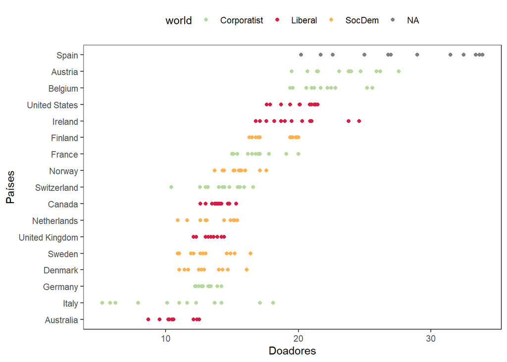

```r
q_5 <- ggplot(organdata,
              aes(x = reorder(country, donors, na.rm = TRUE),
                  y = donors, color = world))
q_5 +
  geom_point() +
  theme_bw() +
  theme(panel.grid = element_blank(),
        legend.position = "top") +
  labs(x = NULL) +
  labs(y = "Doadores",
       x = "Países") +
  scale_color_manual(values = c("#b6d89c", "#d41e45", "#ffb350")) +
  coord_flip()
```

No entanto há algumas sobreposições de pontos, assim podemos utilizar o geom_jitter para realizar essa tarefa de impedir a sobreposição

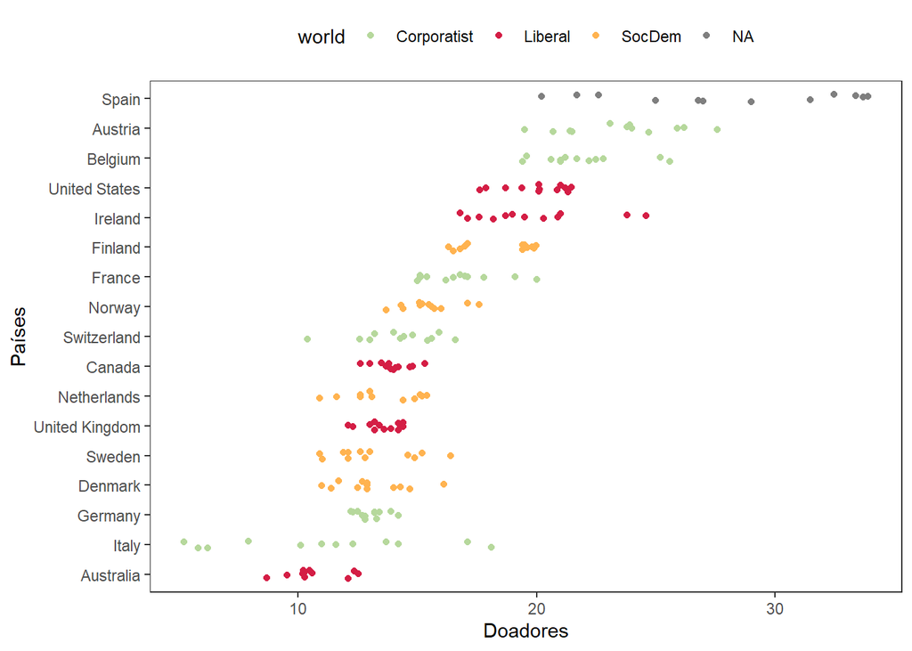

```r
q_5 +
  geom_jitter(position = position_jitter(width = 0.15)) +
  theme_bw() +
  theme(legend.position = "top",
        panel.grid = element_blank()) +
  labs(x = NULL) +
  scale_color_manual(values = c("#b6d89c", "#d41e45", "#ffb350")) +
  labs(y = "Doadores",
       x = "Países") +
  coord_flip()
```

Vamos agora organizar os dados para trabalharmos com a média de cada coisa. Vamos utilizar a deployer, junto com o operador pipe para realizar isso com poucos comandos

```r
por_pais <- organdata %>% group_by(consent_law, country) %>%
  summarize_if(is.numeric, list(mean = mean, sd = sd), na.rm = TRUE) %>%
  ungroup()
tibble(por_pais)
```

```
## # A tibble: 17 × 28
##    consent_law country  donors_mean pop_mean pop_dens_mean gdp_mean gdp_lag_mean
##    <chr>       <chr>          <dbl>    <dbl>         <dbl>    <dbl>        <dbl>
##  1 Informed    Austral…        10.6   18318.         0.237   22179.       21779.
##  2 Informed    Canada          14.0   29608.         0.297   23711.       23353.
##  3 Informed    Denmark         13.1    5257.        12.2     23722.       23275
##  4 Informed    Germany         13.0   80255.        22.5     22163.       21938.
##  5 Informed    Ireland         19.8    3674.         5.23    20824.       20154.
##  6 Informed    Netherl…        13.7   15548.        37.4     23013.       22554.
##  7 Informed    United …        13.5   58187.        24.0     21359.       20962.
##  8 Informed    United …        20.0  269330.         2.80    29212.       28699.
##  9 Presumed    Austria         23.5    7927.         9.45    23876.       23415.
## 10 Presumed    Belgium         21.9   10153.        30.7     22500.       22096.
## 11 Presumed    Finland         18.4    5112.         1.51    21019.       20763
## 12 Presumed    France          16.8   58056.        10.5     22603.       22211.
## 13 Presumed    Italy           11.1   57360.        19.0     21554.       21195.
## 14 Presumed    Norway          15.4    4386.         1.35    26448.       25769.
## 15 Presumed    Spain           28.1   39666.         7.84    16933        16584.
## 16 Presumed    Sweden          13.1    8789.         1.95    22415.       22094
## 17 Presumed    Switzer…        14.2    7037.        17.0     27233        26931.
## # ℹ 21 more variables: health_mean <dbl>, health_lag_mean <dbl>,
## #   pubhealth_mean <dbl>, roads_mean <dbl>, cerebvas_mean <dbl>,
## #   assault_mean <dbl>, external_mean <dbl>, txp_pop_mean <dbl>,
## #   donors_sd <dbl>, pop_sd <dbl>, pop_dens_sd <dbl>, gdp_sd <dbl>,
## #   gdp_lag_sd <dbl>, health_sd <dbl>, health_lag_sd <dbl>, pubhealth_sd <dbl>,
## #   roads_sd <dbl>, cerebvas_sd <dbl>, assault_sd <dbl>, external_sd <dbl>,
## #   txp_pop_sd <dbl>
```

A partir da tabela feita, podemos plotar o gráfico da média de doadores por país. Podemos fazer isso de dois jeitos: O primeiro é separando com cores cada um dos tipos de leis

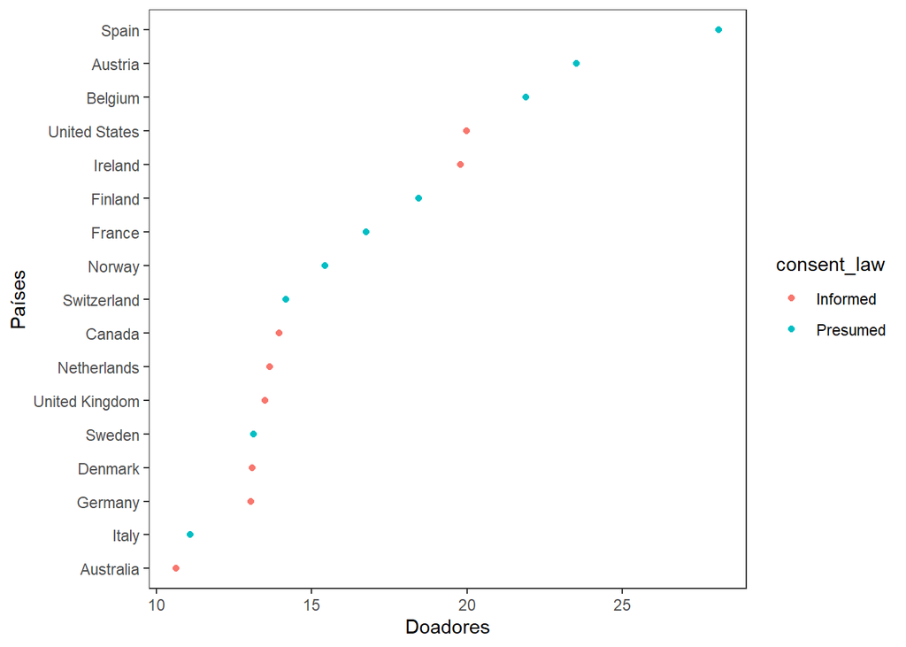

```r
p_6 <- ggplot(por_pais, aes(x = reorder(country, donors_mean), y = donors_mean, color = consent_law))
p_6 +
  geom_point() +
  labs(y = "Doadores",
       x = "Países") +
  coord_flip() +
  theme_bw() +
  theme(panel.grid = element_blank())
```

O segundo é usando o facet_wrap

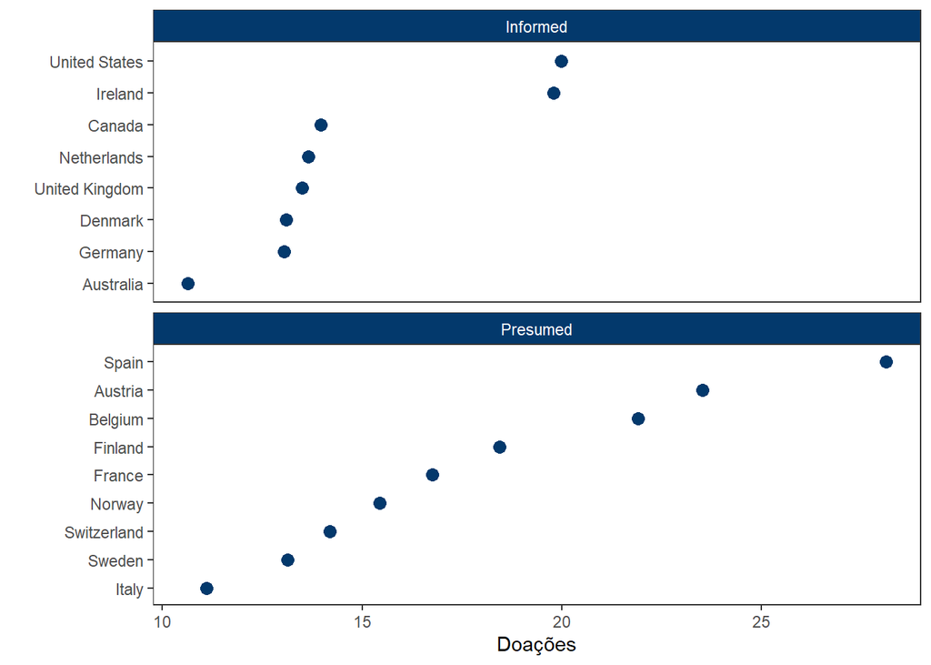

```r
p_7 <- ggplot(por_pais,
              aes(x = donors_mean,
                  y = reorder(country, donors_mean)))
p_7 + geom_point(size = 3, color = "#03396c") +
  facet_wrap(~consent_law,
             scales= "free_y",
             ncol = 1) +
  labs(x = "Doações",
       y = "") +
  theme_bw() +
  theme(panel.grid = element_blank(),
        strip.background = element_rect(fill ="#03396c"),
        strip.text = element_text(color = "white"))
```

De modo a incluir mais informações de variância ou desvio padrão, podemos utilizar o mesmo gráfico anterior, mas ao invés de geom_point, devemos utilizar a função geom_pointrange.

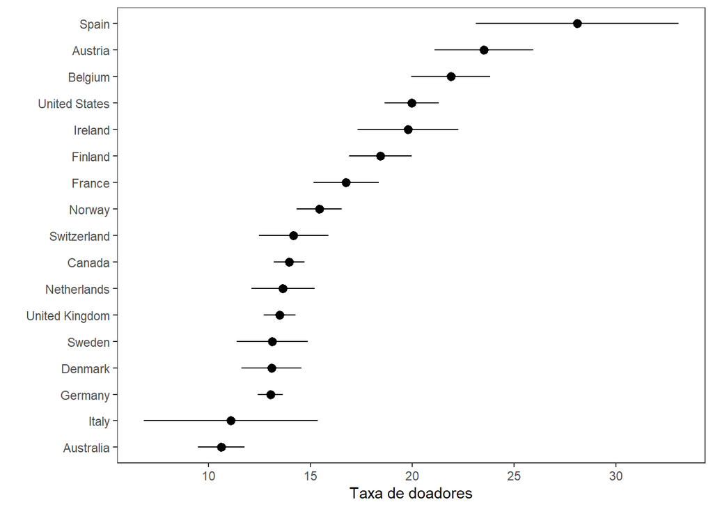

```r
q_6 <- ggplot(por_pais, aes(x = reorder(country, donors_mean), y = donors_mean))
q_6 +
  geom_pointrange(aes(ymin = donors_mean - donors_sd,
                      ymax = donors_mean + donors_sd)) +
  labs(x = "",
       y = "Taxa de doadores") +
  theme_bw() +
  theme(panel.grid = element_blank()) +
  coord_flip()
```

# 4 Plotando textos

Vamos aprender a como plotar textos no R

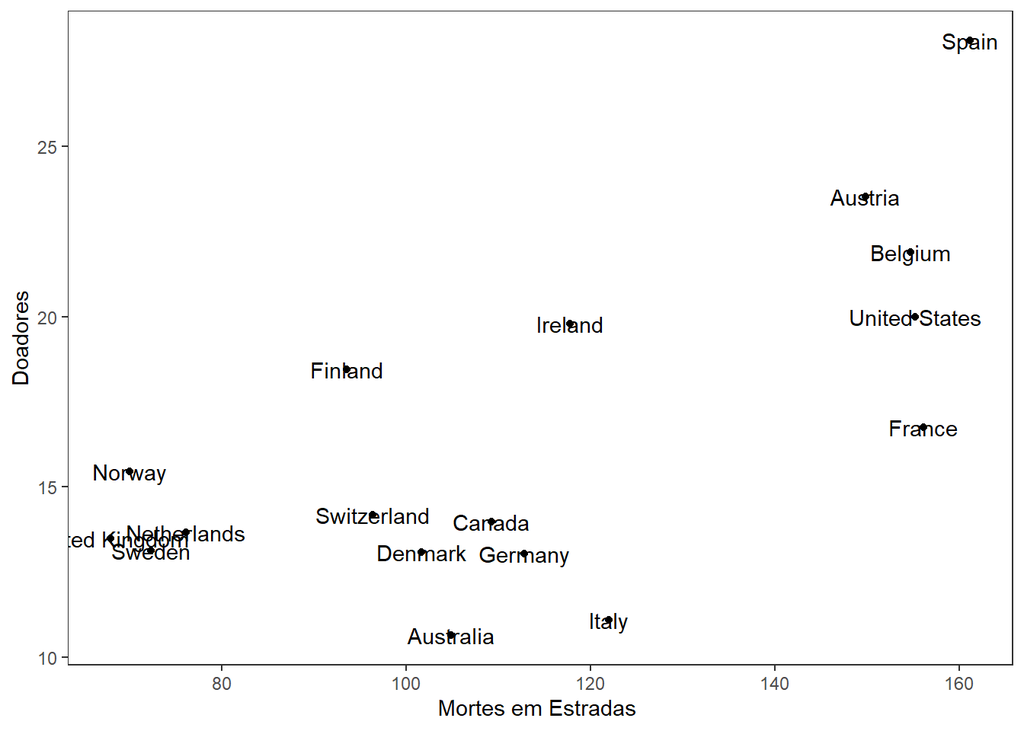

```r
q_7 <- ggplot(por_pais, aes(x = roads_mean, y = donors_mean))
q_7 +
  geom_point() +
  geom_text(aes(label = country)) +
  theme_bw() +
  theme(panel.grid = element_blank()) +
  labs(x = "Mortes em Estradas ",
       y = "Doadores")
```

Desse jeito os nomes ficam todos em cima. Para melhorar podemos adicionar os termos hjust na variável do geom_text para assim melhorar a nossa visualização.

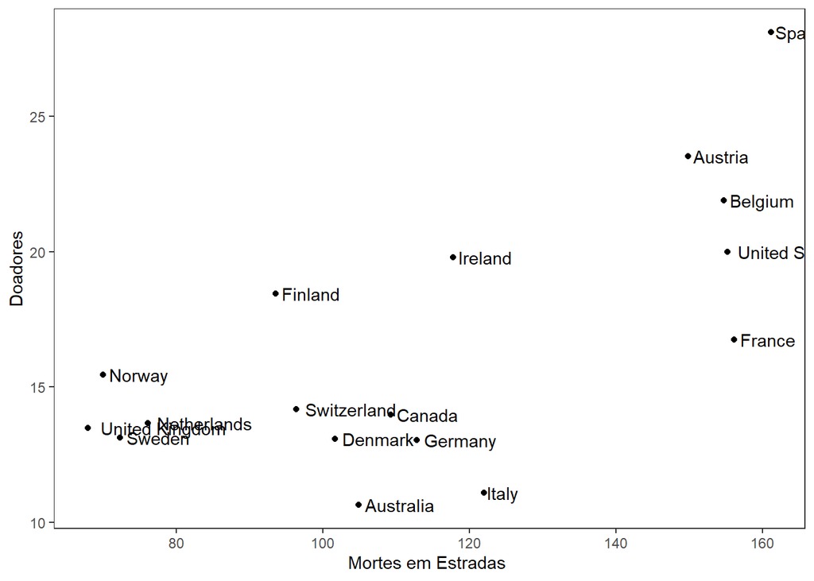

```r
q_7 <- ggplot(por_pais, aes(x = roads_mean, y = donors_mean))
q_7 +
  geom_point() +
  geom_text(aes(label =country), hjust = -0.1) +
  theme_bw() +
  theme(panel.grid = element_blank()) +
  labs(x = "Mortes em Estradas ",
       y = "Doadores")
```